# Statystyczne reguły decyzyjne

### Lato 2021

#### sygnatura przedmiotu: 223490-S

# Selekcja kandydatów do programu akceleracyjnego na podstawie modelu predykcyjnego drzewa decyzyjnego oraz lasów losowych

##### Autorzy raportu:

Damian Borkowski - nr albumu 107531

Piotr Kowalski - nr albumu 72108

Jan Masny - nr albumu 107503

# Spis treści

- Opis problemu
- Eksploracyjna analiza danych
- Budowa modeli predykcyjnych
  - Drzewo decyzyjne
  - Lasy losowe
  - Graficzna ocena klasyfikatorów - krzywa ROC
- Wnioski i rekomendacje
- Bibliogriafia

# Opis problemu

Pewna firma ABC otrzymała od jednego z klientów zadanie wsparcia jej programu akceleracyjnego. Na podstawie danych z 2014 roku stworzony został zbiór danych (dane zostały wybrane według ustalonych kryteriów) firm wraz z informacją czy firmie udało się przetrwać do 1.01.2016. Zadaniem jest zbudowanie modelu predykcyjnego, który ma dokonywać negatywnej selekcji kandydatów do programu akceleracyjnego. Do tego celu zdecydowano się stworzyć model predykcyjny drzewa decyzyjnych oraz lasów losowych, a następnie porównano osiągane przez nie wyniki.

Zmienne:

- SECTOR - typ działalności
- EMPLOYEES - liczba pracowników
- INCOME - przychód w 2014
- MARKETING_SPENDING - pieniądze wydane na marketing
- ACC_BEFORE - czy firma korzystała wcześniej z wsparcia akceleracyjnego
- PRESS_INDEX - wartość wyznaczonego przez analityków indeksu pozytywnego przekazu w mediach
- FB_LIKES - liczba polubień na Facebooku
- TWT_FOLLOWERS - liczba obserwujących na Twitterze
- YEAR_FOUNDED - rok założenia
- EXP_CEO - lata doświadczenia prezesa na podstawie serwisu LinkedIn
- AREA - powierzchnia biura
- HIRED - liczba aktualnie pracujących osób w firmie ABC wywodzących się z danej firmy
- CREDIT - wartość niespłaconych kredytów
- FLAG - informacja czy firma upadła do 1.01.2016 r

*dane wykorzystane w niniejszej pracy pochodzą z zadania wstępnego na program mentoringowy do jedenej z firm z tzw. wielkiej czwórki*

```python
import numpy as np
import pandas as pd
import seaborn as sns
import pydotplus
from matplotlib import pyplot as plt
from category_encoders.ordinal import OrdinalEncoder
from sklearn.preprocessing import StandardScaler
from sklearn.model_selection import train_test_split, GridSearchCV
from sklearn.tree import DecisionTreeClassifier, export_graphviz
from sklearn.metrics import classification_report, confusion_matrix, roc_curve, roc_auc_score, plot_roc_curve
from sklearn.ensemble import RandomForestClassifier
from io import StringIO
from IPython.display import display, Image
np.random.seed(1)
```

# Eksploracyjna analiza danych

##### Wczytanie danych

```python
df = pd.read_csv("acceleration_srd.csv")
print(df.shape)
df.head()
```

```
(10000, 14)
```

|  | SECTOR | EMPLOYEES | INCOME | MARKETING_SPENDING | ACC_BEFORE | PRESS_INDEX | FB_LIKES | TWT_FOLLOWERS | YEAR_FOUNDED | EXP_CEO | AREA | HIRED | CREDIT | FLAG |
| --- | --- | --- | --- | --- | --- | --- | --- | --- | --- | --- | --- | --- | --- | --- |
| 0 | PUB | 2 | 150426.0 | 7964 | 0 | -8.078335 | 1633 | 138 | 2010 | NaN | 32 | 0 | 19950 | 0 |
| 1 | PUB | 6 | 500078.0 | 30212 | 0 | 17.032851 | 6128 | 605 | 2011 | NaN | 44 | 1 | 45104 | 1 |
| 2 | IT | 27 | 199767.0 | 4970 | 0 | -7.321621 | 487 | 106 | 2005 | NaN | 83 | 0 | 499 | 0 |
| 3 | IT | 5 | 109200.0 | 7010 | 1 | 1.135431 | 661 | 116 | 2011 | NaN | 21 | 1 | 0 | 1 |
| 4 | IT | 3 | 112200.0 | 9000 | 0 | 0.950873 | 926 | 172 | 2012 | 5.0 | 23 | 0 | -997 | 1 |

```python
df.columns
```

```
Index(['SECTOR', 'EMPLOYEES', 'INCOME', 'MARKETING_SPENDING', 'ACC_BEFORE',
       'PRESS_INDEX', 'FB_LIKES', 'TWT_FOLLOWERS', 'YEAR_FOUNDED', 'EXP_CEO',
       'AREA', 'HIRED', 'CREDIT', 'FLAG'],
      dtype='object')
```

```python
df.iloc[100:110]
```

|  | SECTOR | EMPLOYEES | INCOME | MARKETING_SPENDING | ACC_BEFORE | PRESS_INDEX | FB_LIKES | TWT_FOLLOWERS | YEAR_FOUNDED | EXP_CEO | AREA | HIRED | CREDIT | FLAG |
| --- | --- | --- | --- | --- | --- | --- | --- | --- | --- | --- | --- | --- | --- | --- |
| 100 | IT | 5 | 80002.0 | 7600 | 0 | -0.385880 | 789 | 152 | 2011 | 6.0 | 77 | 1 | 19076 | 1 |
| 101 | CAFE | 3 | 150246.0 | 7900 | 0 | -11.815892 | 1590 | 149 | 2009 | NaN | 31 | 0 | 17000 | 0 |
| 102 | IT | 6 | 69843.0 | 6586 | 0 | 1.860027 | 673 | 138 | 2012 | 2.0 | 83 | 0 | 21106 | 1 |
| 103 | IT | 20 | 404000.0 | 54070 | 0 | 3.520488 | 5468 | 1151 | 2006 | NaN | 200 | 3 | 60194 | 1 |
| 104 | IT | 46 | 373380.0 | 10066 | 0 | -2.955386 | 1027 | 200 | 2002 | 13.0 | 335 | 2 | 990 | 1 |
| 105 | IT | 3 | 199811.0 | 5081 | 0 | -4.012788 | 535 | 90 | 2005 | NaN | 71 | 1 | 795 | 1 |
| 106 | IT | 3 | 200218.0 | 5077 | 0 | -5.781295 | 485 | 107 | 2006 | NaN | 74 | 2 | 702 | 0 |
| 107 | IT | 35 | 199832.0 | 4972 | 1 | -2.106397 | 471 | 105 | 1998 | 7.0 | 74 | 0 | 596 | 0 |
| 108 | IT | 29 | 199974.0 | 4839 | 0 | -4.920787 | 468 | 98 | 1999 | NaN | 72 | 0 | 0 | 0 |
| 109 | PUB | 5 | 498900.0 | 29806 | 0 | 24.748104 | 6043 | 606 | 2013 | 2.0 | 52 | 0 | 39967 | 0 |

```python
df.dtypes
```

```
SECTOR                 object
EMPLOYEES               int64
INCOME                float64
MARKETING_SPENDING      int64
ACC_BEFORE              int64
PRESS_INDEX           float64
FB_LIKES                int64
TWT_FOLLOWERS           int64
YEAR_FOUNDED            int64
EXP_CEO               float64
AREA                    int64
HIRED                   int64
CREDIT                  int64
FLAG                    int64
dtype: object
```

```python
df.describe()
```

|  | EMPLOYEES | INCOME | MARKETING_SPENDING | ACC_BEFORE | PRESS_INDEX | FB_LIKES | TWT_FOLLOWERS | YEAR_FOUNDED | EXP_CEO | AREA | HIRED | CREDIT | FLAG |
| --- | --- | --- | --- | --- | --- | --- | --- | --- | --- | --- | --- | --- | --- |
| count | 10000.000000 | 10000.000000 | 10000.000000 | 10000.000000 | 10000.000000 | 10000.000000 | 10000.000000 | 10000.000000 | 5603.000000 | 10000.000000 | 10000.000000 | 1.000000e+04 | 10000.000000 |
| mean | 12.956300 | 232443.375500 | 13515.335200 | 0.336400 | -0.681005 | 1919.496800 | 270.476500 | 2006.907200 | 6.603070 | 91.014600 | 1.502500 | 2.775444e+05 | 0.526100 |
| std | 15.100622 | 137466.555775 | 12037.821285 | 0.472501 | 8.357843 | 1829.979996 | 241.681628 | 4.612973 | 3.117685 | 95.869246 | 1.852225 | 1.605495e+06 | 0.499343 |
| min | 1.000000 | -900.000000 | 830.000000 | 0.000000 | -38.793253 | 91.000000 | 16.000000 | 1989.000000 | 1.000000 | 11.000000 | 0.000000 | -9.830000e+03 | 0.000000 |
| 25% | 3.000000 | 149647.000000 | 5136.750000 | 0.000000 | -5.040576 | 542.000000 | 118.000000 | 2004.000000 | 4.000000 | 31.000000 | 0.000000 | 0.000000e+00 | 0.000000 |
| 50% | 5.000000 | 199734.000000 | 8038.000000 | 0.000000 | -1.186027 | 1223.000000 | 165.000000 | 2007.000000 | 6.000000 | 63.000000 | 1.000000 | 1.207000e+03 | 1.000000 |
| 75% | 21.000000 | 312862.500000 | 11970.000000 | 1.000000 | 2.676324 | 1656.000000 | 232.250000 | 2011.000000 | 8.000000 | 75.000000 | 2.000000 | 2.105125e+04 | 1.000000 |
| max | 63.000000 | 647000.000000 | 68180.000000 | 1.000000 | 59.938575 | 6893.000000 | 1410.000000 | 2014.000000 | 21.000000 | 387.000000 | 15.000000 | 1.313101e+07 | 1.000000 |

```python
df.info()
```

```
<class 'pandas.core.frame.DataFrame'>
RangeIndex: 10000 entries, 0 to 9999
Data columns (total 14 columns):
 #   Column              Non-Null Count  Dtype
---  ------              --------------  -----
 0   SECTOR              10000 non-null  object
 1   EMPLOYEES           10000 non-null  int64
 2   INCOME              10000 non-null  float64
 3   MARKETING_SPENDING  10000 non-null  int64
 4   ACC_BEFORE          10000 non-null  int64
 5   PRESS_INDEX         10000 non-null  float64
 6   FB_LIKES            10000 non-null  int64
 7   TWT_FOLLOWERS       10000 non-null  int64
 8   YEAR_FOUNDED        10000 non-null  int64
 9   EXP_CEO             5603 non-null   float64
 10  AREA                10000 non-null  int64
 11  HIRED               10000 non-null  int64
 12  CREDIT              10000 non-null  int64
 13  FLAG                10000 non-null  int64
dtypes: float64(3), int64(10), object(1)
memory usage: 1.1+ MB
```

##### Sprawdzenie liczby unikalnych wartości dla każdej zmiennej

```python
for column in df:
    unique_values = np.unique(df[column])
    nr_values = len(unique_values)
    if nr_values < 10:
        print("The number of values for feature {} is: {} -- {}".format(column, nr_values, unique_values))
    else:
        print("The number of values for feature {} is: {}".format(column, nr_values))
```

```
The number of values for feature SECTOR is: 4 -- ['CAFE' 'IT' 'PUB' 'RESTAURANT']
The number of values for feature EMPLOYEES is: 60
The number of values for feature INCOME is: 5201
The number of values for feature MARKETING_SPENDING is: 2623
The number of values for feature ACC_BEFORE is: 2 -- [0 1]
The number of values for feature PRESS_INDEX is: 10000
The number of values for feature FB_LIKES is: 2291
The number of values for feature TWT_FOLLOWERS is: 847
The number of values for feature YEAR_FOUNDED is: 26
The number of values for feature EXP_CEO is: 4417
The number of values for feature AREA is: 207
The number of values for feature HIRED is: 16
The number of values for feature CREDIT is: 4050
The number of values for feature FLAG is: 2 -- [0 1]
```

##### Graficzne przedstawienie wartości zmiennych

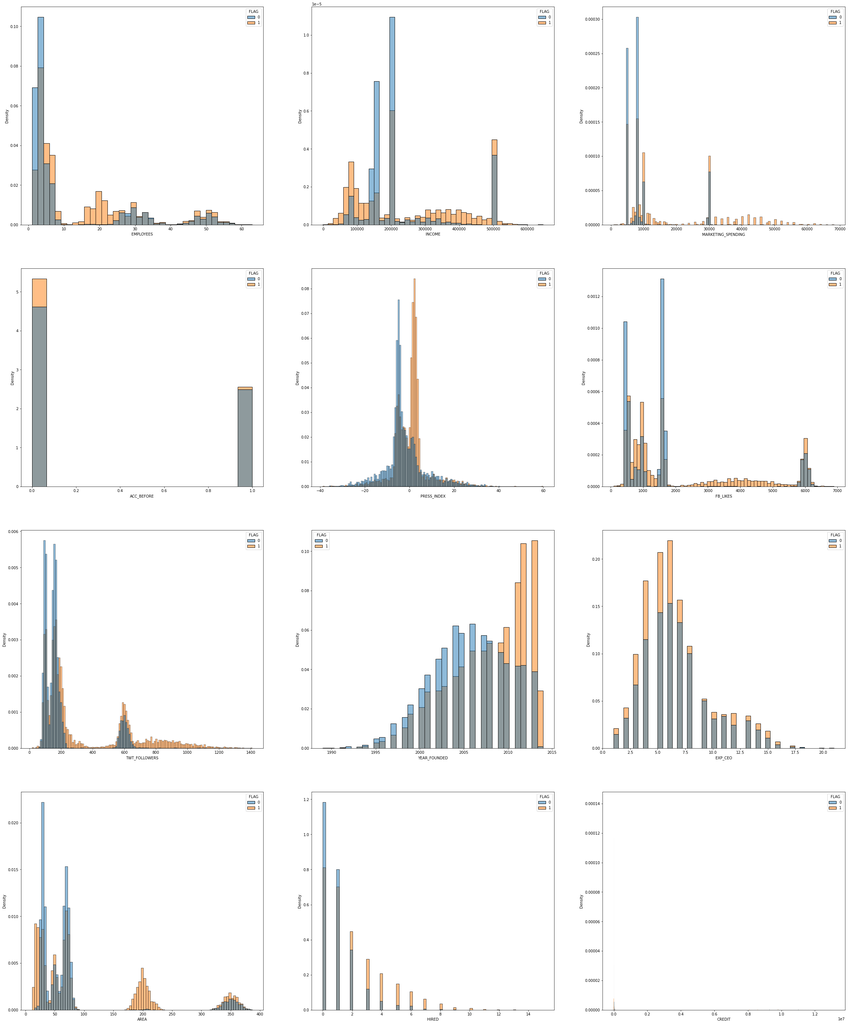

```python
fig, axes = plt.subplots(4,3, figsize= (40, 50))
for i, var in enumerate(['EMPLOYEES', 'INCOME', 'MARKETING_SPENDING', 'ACC_BEFORE', 'PRESS_INDEX', 'FB_LIKES', 'TWT_FOLLOWERS', 'YEAR_FOUNDED', 'EXP_CEO', 'AREA', 'HIRED', 'CREDIT']):
    sns.histplot(df, x=var, hue='FLAG', stat="density", ax=axes[i//3,i%3])
```

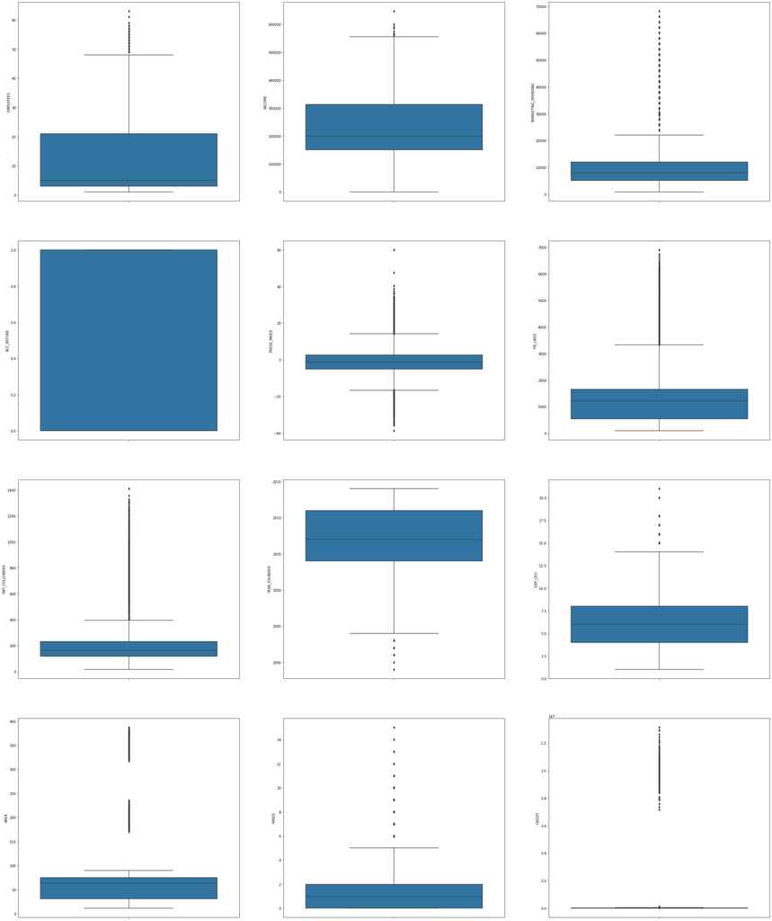

```python
fig, axes = plt.subplots(4,3, figsize= (40, 50))
for i, var in enumerate(['EMPLOYEES', 'INCOME', 'MARKETING_SPENDING', 'ACC_BEFORE', 'PRESS_INDEX', 'FB_LIKES', 'TWT_FOLLOWERS', 'YEAR_FOUNDED', 'EXP_CEO', 'AREA', 'HIRED', 'CREDIT']):
    sns.boxplot(y=var,data=df, ax=axes[i//3,i%3])
```

##### Histogram rozkładu zmiennej celu

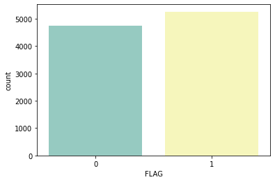

```python
sns.countplot(x = 'FLAG', data = df, palette = 'Set3')
```

##### Imputacja danych w miejsce braków danych

```python
df.isnull().mean()
```

```
SECTOR                0.0000
EMPLOYEES             0.0000
INCOME                0.0000
MARKETING_SPENDING    0.0000
ACC_BEFORE            0.0000
PRESS_INDEX           0.0000
FB_LIKES              0.0000
TWT_FOLLOWERS         0.0000
YEAR_FOUNDED          0.0000
EXP_CEO               0.4397
AREA                  0.0000
HIRED                 0.0000
CREDIT                0.0000
FLAG                  0.0000
dtype: float64
```

```python
# braki danych w zmiennej EXP_CEO zostały zastąpione wartością '-1'
df_one = df.fillna(-1)
print(df_one.shape)
df_one.head()
```

```
(10000, 14)
```

|  | SECTOR | EMPLOYEES | INCOME | MARKETING_SPENDING | ACC_BEFORE | PRESS_INDEX | FB_LIKES | TWT_FOLLOWERS | YEAR_FOUNDED | EXP_CEO | AREA | HIRED | CREDIT | FLAG |
| --- | --- | --- | --- | --- | --- | --- | --- | --- | --- | --- | --- | --- | --- | --- |
| 0 | PUB | 2 | 150426.0 | 7964 | 0 | -8.078335 | 1633 | 138 | 2010 | -1.0 | 32 | 0 | 19950 | 0 |
| 1 | PUB | 6 | 500078.0 | 30212 | 0 | 17.032851 | 6128 | 605 | 2011 | -1.0 | 44 | 1 | 45104 | 1 |
| 2 | IT | 27 | 199767.0 | 4970 | 0 | -7.321621 | 487 | 106 | 2005 | -1.0 | 83 | 0 | 499 | 0 |
| 3 | IT | 5 | 109200.0 | 7010 | 1 | 1.135431 | 661 | 116 | 2011 | -1.0 | 21 | 1 | 0 | 1 |
| 4 | IT | 3 | 112200.0 | 9000 | 0 | 0.950873 | 926 | 172 | 2012 | 5.0 | 23 | 0 | -997 | 1 |

```python
df_one.isnull().mean()
```

```
SECTOR                0.0
EMPLOYEES             0.0
INCOME                0.0
MARKETING_SPENDING    0.0
ACC_BEFORE            0.0
PRESS_INDEX           0.0
FB_LIKES              0.0
TWT_FOLLOWERS         0.0
YEAR_FOUNDED          0.0
EXP_CEO               0.0
AREA                  0.0
HIRED                 0.0
CREDIT                0.0
FLAG                  0.0
dtype: float64
```

##### Kategoryzacja zmiennej jakościowej

```python
# ordinal encoding - SECTOR
encoder = OrdinalEncoder(
 mapping = [
     {
         'col':'SECTOR',
         'mapping': {'CAFE': 1, 'IT': 2, 'PUB': 3, 'RESTAURANT': 4}
     }
 ])
```

```python
print(df_one.shape)
df_one_ordinal = encoder.fit_transform(df_one)
print(df_one_ordinal.shape)
df_one_ordinal.head()
```

```
(10000, 14)
(10000, 14)
```

|  | SECTOR | EMPLOYEES | INCOME | MARKETING_SPENDING | ACC_BEFORE | PRESS_INDEX | FB_LIKES | TWT_FOLLOWERS | YEAR_FOUNDED | EXP_CEO | AREA | HIRED | CREDIT | FLAG |
| --- | --- | --- | --- | --- | --- | --- | --- | --- | --- | --- | --- | --- | --- | --- |
| 0 | 3 | 2 | 150426.0 | 7964 | 0 | -8.078335 | 1633 | 138 | 2010 | -1.0 | 32 | 0 | 19950 | 0 |
| 1 | 3 | 6 | 500078.0 | 30212 | 0 | 17.032851 | 6128 | 605 | 2011 | -1.0 | 44 | 1 | 45104 | 1 |
| 2 | 2 | 27 | 199767.0 | 4970 | 0 | -7.321621 | 487 | 106 | 2005 | -1.0 | 83 | 0 | 499 | 0 |
| 3 | 2 | 5 | 109200.0 | 7010 | 1 | 1.135431 | 661 | 116 | 2011 | -1.0 | 21 | 1 | 0 | 1 |
| 4 | 2 | 3 | 112200.0 | 9000 | 0 | 0.950873 | 926 | 172 | 2012 | 5.0 | 23 | 0 | -997 | 1 |

##### Podział danych na zbiór treningowy i testowy - zbiór testowy zawiera 20% wszystkich obserwacji

```python
df_one_ordinal_train, df_one_ordinal_test = train_test_split(df_one_ordinal, test_size=0.2)

x_train = df_one_ordinal_train.copy()
x_train = x_train.drop(columns=['FLAG'])
x_test = df_one_ordinal_test.copy()
x_test = x_test.drop(columns=['FLAG'])

y_train = df_one_ordinal_train.copy()
y_train = y_train['FLAG']
y_test = df_one_ordinal_test.copy()
y_test = y_test['FLAG']
```

##### Standrayzacja zmiennych ilościowych

```python
scaler = StandardScaler()
scaler.fit(x_train)

x_train = scaler.transform(x_train)
x_test = scaler.transform(x_test)
```

# Budowa modeli predykcyjnych

### Drzewa decyzyjne

Tworzymy wstępny model drzewa decyzyjnego do problemu klasyfikacyjnego przy domyślnych hiperparametrach.

```python
# Create Decision Tree classifer object
DTC_def = DecisionTreeClassifier()

# Train Decision Tree Classifer
DTC_def = DTC_def.fit(x_train,y_train)

#Predict the response for test dataset
y_pred = DTC_def.predict(x_test)
print(classification_report(y_test, y_pred))
```

```
              precision    recall  f1-score   support

           0       0.70      0.72      0.71       940
           1       0.74      0.72      0.73      1060

    accuracy                           0.72      2000
   macro avg       0.72      0.72      0.72      2000
weighted avg       0.72      0.72      0.72      2000
```

Następnie stworzony został kolejny model drzewa decyzyjnego do problemu klasyfikacyjnego przy zmianie parametru "zanieczyszczenia"(criterion -->gini, criterion --> entropy):

- **max_depth:** Maksymalna głębokość drzewa.
- **random_state:** Kontroluje losowość estymatora.
- **max_features:** Liczba cech, które należy wziąć pod uwagę przy poszukiwaniu najlepszego podziału.
- **min_samples_split:** Minimalna liczba próbek wymagana do podziału węzła.

W tym modelu wartość hiperparametrów została dobrane ręcznie.

```python
DTC = DecisionTreeClassifier(criterion="entropy", max_depth=6, random_state = 12, max_features=10, min_samples_split=560)

# Train Decision Tree Classifer
DTC = DTC.fit(x_train,y_train)

#Predict the response for test dataset
y_pred = DTC.predict(x_test)

# Model Accuracy, how often is the classifier correct?
print(classification_report(y_test, y_pred))
```

```
              precision    recall  f1-score   support

           0       0.75      0.70      0.73       940
           1       0.75      0.80      0.77      1060

    accuracy                           0.75      2000
   macro avg       0.75      0.75      0.75      2000
weighted avg       0.75      0.75      0.75      2000
```

##### Graficzne przedstawienie drzewa decyzyjnego przy ręcznie dobranych hiperparametrach

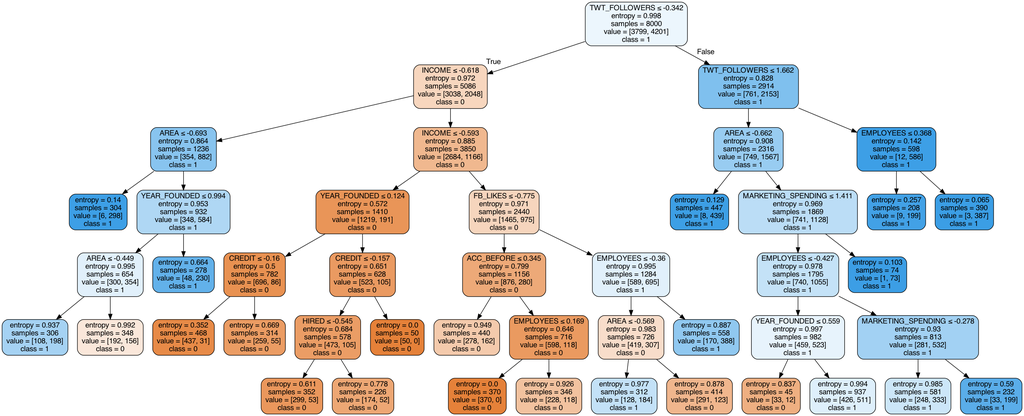

```python
feature_cols = ['SECTOR','EMPLOYEES', 'INCOME', 'MARKETING_SPENDING', 'ACC_BEFORE', 'PRESS_INDEX', 'FB_LIKES', 'TWT_FOLLOWERS', 'YEAR_FOUNDED', 'EXP_CEO', 'AREA', 'HIRED', 'CREDIT']
dot_data = StringIO()
export_graphviz(DTC, out_file=dot_data,
                filled=True, rounded=True,
                special_characters=True,feature_names = feature_cols,class_names=['0','1'])
graph = pydotplus.graph_from_dot_data(dot_data.getvalue())
graph.write_png('acceleration_srd.png')
Image(graph.create_png())
```

```python
# polecenie opcjonalne jeśli pojawią się problemy z instalacja biblioteki graphviz
# from sklearn.tree import plot_tree
# plt.figure(figsize=(60,30))
# plot_tree(DTC, filled=True);
```

##### Dobór optymalnych wartości dla hiperparametrów przez funkcję GridSearchCV

GridSearchCV przechodzi przez wszystkie możliwe wartości podane przez użytkownika, które są wprowadzane do tablicy parametrów i tworzy ich najlepszą kombinację, w oparciu o metrykę punktową według własnego wyboru (dokładność, f1, itp.). Proces ten jest czasochłonny jednak pozwala na osiągnięcie wyższych wartości dopasowania, nie przechodząc przez wszystkie hiperparametry ręcznie.

```python
tree_param = [{'max_features': np.arange(1, 14), 'max_depth': np.arange(1,11),'min_samples_split': [2, 100, 200, 300, 400, 500, 600, 700, 800, 900, 1000] }]
DTC = GridSearchCV(DecisionTreeClassifier(), tree_param, cv=7)
DTC.fit(x_train,y_train)
```

```
GridSearchCV(cv=7, estimator=DecisionTreeClassifier(),
             param_grid=[{'max_depth': array([ 1,  2,  3,  4,  5,  6,  7,  8,  9, 10]),
                          'max_features': array([ 1,  2,  3,  4,  5,  6,  7,  8,  9, 10, 11, 12, 13]),
                          'min_samples_split': [2, 100, 200, 300, 400, 500, 600,
                                                700, 800, 900, 1000]}])
```

Najlepsze wartości dobrane poprzez funkcję GridSearchCV

```python
print('Best Criterion:', DTC.best_estimator_.get_params()['criterion'])
print('Max Depth:', DTC.best_estimator_.get_params()['max_depth'])
print('Max Features:', DTC.best_estimator_.get_params()['max_features'])
print('Min Samples Split:', DTC.best_estimator_.get_params()['min_samples_split'])
```

```
Best Criterion: gini
Max Depth: 7
Max Features: 12
Min Samples Split: 100
```

```python
DTC = DecisionTreeClassifier(criterion="gini", max_depth = 8, max_features = 7, random_state=42, min_samples_split=300)

DTC = DTC.fit(x_train,y_train)

y_pred = DTC.predict(x_test)

print(classification_report(y_test, y_pred))
```

```
              precision    recall  f1-score   support

           0       0.73      0.65      0.69       940
           1       0.72      0.78      0.75      1060

    accuracy                           0.72      2000
   macro avg       0.72      0.72      0.72      2000
weighted avg       0.72      0.72      0.72      2000
```

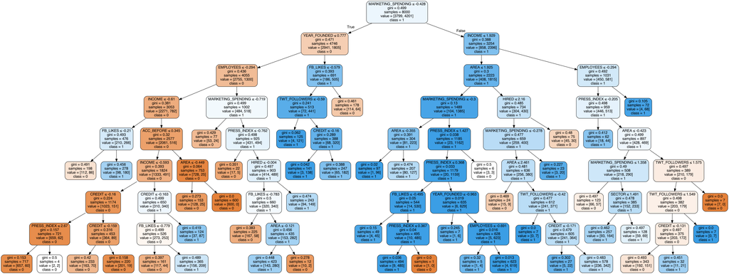

```python
feature_cols = ['SECTOR','EMPLOYEES', 'INCOME', 'MARKETING_SPENDING', 'ACC_BEFORE', 'PRESS_INDEX', 'FB_LIKES', 'TWT_FOLLOWERS', 'YEAR_FOUNDED', 'EXP_CEO', 'AREA', 'HIRED', 'CREDIT']
dot_data = StringIO()
export_graphviz(DTC, out_file=dot_data,
                filled=True, rounded=True,
                special_characters=True,feature_names = feature_cols,class_names=['0','1'])
graph = pydotplus.graph_from_dot_data(dot_data.getvalue())
graph.write_png('acceleration_srd_GSCV.png')
Image(graph.create_png())
```

```python
# polecenie opcjonalne jeśli pojawią się problemy z instalacja biblioteki graphviz
# from sklearn.tree import plot_tree
# plt.figure(figsize=(60,30))
# plot_tree(DTC, filled=True);
```

##### Lista najistotniejszych zmiennych

```python
feature_imp = pd.Series(DTC.feature_importances_,index=feature_cols).sort_values(ascending=False)
feature_imp
```

```
MARKETING_SPENDING    0.329128
INCOME                0.199881
YEAR_FOUNDED          0.122882
AREA                  0.095958
FB_LIKES              0.087814
EMPLOYEES             0.077495
ACC_BEFORE            0.036662
CREDIT                0.026392
PRESS_INDEX           0.008976
TWT_FOLLOWERS         0.008105
HIRED                 0.005671
SECTOR                0.001036
EXP_CEO               0.000000
dtype: float64
```

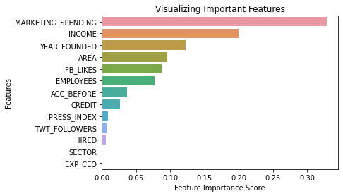

```python
sns.barplot(x=feature_imp, y=feature_imp.index)
plt.xlabel('Feature Importance Score')
plt.ylabel('Features')
plt.title("Visualizing Important Features")
plt.show()
```

### Lasy losowe

Tworzymy wstępny model lasów losowych do problemu klasyfikacyjnego przy domyślnych hiperparametrach.

```python
#Create a Gaussian Classifier
RFC_def=RandomForestClassifier()

#Train the model using the training sets y_pred=clf.predict(X_test)
RFC_def.fit(x_train,y_train)

y_pred=RFC_def.predict(x_test)

print(classification_report(y_test, y_pred))
```

```
              precision    recall  f1-score   support

           0       0.74      0.72      0.73       940
           1       0.76      0.78      0.77      1060

    accuracy                           0.75      2000
   macro avg       0.75      0.75      0.75      2000
weighted avg       0.75      0.75      0.75      2000
```

##### Dobór optymalnych wartości dla hiperparametrów przez funkcję GridSearchCV

**Uwaga!** - czas trwania obliczeń to ok. 45 min.

```python
param_grid = {
    'bootstrap': [True],
    'max_depth': [1,3,5,7,10],
    'max_features': [1,3,5,7,10],
    'min_samples_leaf': [3, 4, 5],
    'min_samples_split': [8, 10, 12],
    'n_estimators': [100, 200, 300, 1000]}
```

```python
RFC = GridSearchCV(RandomForestClassifier(), param_grid,
                          cv = 3, n_jobs = -1, verbose = 2)
RFC = RFC.fit(x_train,y_train)

y_pred = RFC.predict(x_test)

print(classification_report(y_test, y_pred))
```

```
Fitting 3 folds for each of 900 candidates, totalling 2700 fits
              precision    recall  f1-score   support

           0       0.76      0.69      0.73       940
           1       0.75      0.81      0.78      1060

    accuracy                           0.76      2000
   macro avg       0.76      0.75      0.75      2000
weighted avg       0.76      0.76      0.75      2000
```

```python
print('Criterion:', RFC.best_estimator_.get_params()['criterion'])
print('Max Depth:', RFC.best_estimator_.get_params()['max_depth'])
print('Max Features:', RFC.best_estimator_.get_params()['max_features'])
print('Min Samples Leaf:', RFC.best_estimator_.get_params()['min_samples_leaf'])
print('N Estimators:', RFC.best_estimator_.get_params()['n_estimators'])
print('Min Samples Split:', RFC.best_estimator_.get_params()['min_samples_split'])
print('Bootstrap:', RFC.best_estimator_.get_params()['bootstrap'])
```

```
Criterion: gini
Max Depth: 10
Max Features: 5
Min Samples Leaf: 5
N Estimators: 100
Min Samples Split: 10
Bootstrap: True
```

##### Model zbudowany w oparciu o najlepsze wartości dobrane poprzez funkcję GridSearchCV

```python
RFC = RandomForestClassifier(criterion="gini", max_depth=10, max_features = 5, random_state=42, min_samples_leaf=5, n_estimators = 100, min_samples_split = 10)

RFC = RFC.fit(x_train,y_train)

y_pred = RFC.predict(x_test)

print(classification_report(y_test, y_pred))
```

```
              precision    recall  f1-score   support

           0       0.76      0.70      0.73       940
           1       0.75      0.81      0.78      1060

    accuracy                           0.76      2000
   macro avg       0.76      0.75      0.75      2000
weighted avg       0.76      0.76      0.76      2000
```

##### Lista najistotniejszych zmiennych

```python
feature_imp = pd.Series(RFC.feature_importances_,index=feature_cols).sort_values(ascending=False)
feature_imp
```

```
INCOME                0.180928
MARKETING_SPENDING    0.154108
FB_LIKES              0.107441
TWT_FOLLOWERS         0.094432
PRESS_INDEX           0.093591
AREA                  0.087856
EMPLOYEES             0.085372
YEAR_FOUNDED          0.055718
CREDIT                0.054494
ACC_BEFORE            0.038746
SECTOR                0.019773
HIRED                 0.015398
EXP_CEO               0.012144
dtype: float64
```

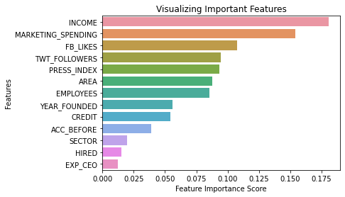

```python
sns.barplot(x=feature_imp, y=feature_imp.index)
plt.xlabel('Feature Importance Score')
plt.ylabel('Features')
plt.title("Visualizing Important Features")
plt.show()
```

### Graficzna ocena klasyfikatorów - krzywa ROC

##### Wizualizacja krzywej ROC dla modelu lasów losowych oraz drzewa decyzyjnego. Hiperparametry domyślne.

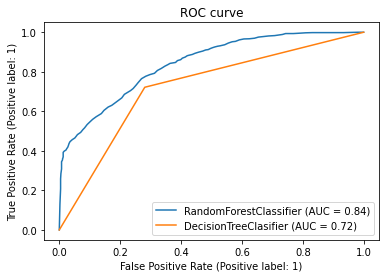

```python
fig, ax = plt.subplots()

models = [
    ("RandomForestClassifier", RFC_def),
    ("DecisionTreeClasifier", DTC_def),
]

model_displays = {}
for name, pipeline in models:
    model_displays[name] = plot_roc_curve(
        pipeline, x_test, y_test, ax=ax, name=name)
_ = ax.set_title('ROC curve')
```

##### Wizualizacja krzywej ROC dla modelu lasów losowych oraz drzewa decyzyjnego. Hiperparametry dobrane przez GridSearchCV.

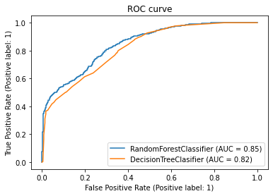

```python
fig, ax = plt.subplots()

models = [
    ("RandomForestClassifier", RFC),
    ("DecisionTreeClasifier", DTC),
]

model_displays = {}
for name, pipeline in models:
    model_displays[name] = plot_roc_curve(
        pipeline, x_test, y_test, ax=ax, name=name)
_ = ax.set_title('ROC curve')
```

# Wnioski i rekomendacje

W celu opracowania modelu predykcyjnego do selekcji odpowiednich kandydatów do programu akcelaracyjnego wykorzystano dwie metody:

- model wykorzystujący do predykcji metodę drzew decyzyjnych
- model wykorzystujący do predykcji metodą lasów losowych

Dla każdej metody stworzono model podstawowy, a następnie przeprowadzono analizę metodą GridSearchCV w celu znalezienia najlepszych hiperparametrów dla danego modelu.

W przypadku końcowego modelu **lasów losowych** uzyskano następujące wartości hiperparametrów:

- Best Criterion: gini
- Max Depth: 10
- Max Features: 5
- Min Samples Leaf: 5
- N Estimators: 100
- Min Samples Split: 10
- Bootstrap: True

Pięć najważniejszych zmiennych według oszacowanań końcowego modelu **drzewa decyzyjnego** to:

- MARKETING_SPENDING
- INCOME
- YEAR_FOUNDED
- AREA
- FB_LIKES

Pięć najważniejszych zmiennych według oszacowanań końcowego modelu **lasów losowych** to:

- INCOME
- MARKETING_SPENDING
- FB_LIKES
- TWT_FOLLOWERS
- PRESS_INDEX

*(zmienne uporządkowane są od najważniejszej do najmniej ważnej)*

Macierz pomyłek końcowego modelu **drzewa decyzyjnego**:

- dokładność: 0.72
- precyzja: 0.72
- czułość: 0.78
- F1-score: 0.75

Macierz pomyłek końcowego modelu **lasów losowych**:

- dokładność: 0.76
- precyzja: 0.75
- czułość: 0.81
- F1-score: 0.78

Wykres ROC końcowego modelu **drzewa decyzyjnego**:

- wartość pola pod krzywą (AUC) wynosi 0.82, co jest znaczącą poprawą względem wartości AUC równej 0.72, która otrzymana została w modelu podstawowym drzewa decyzyjnego. Można uznać, że przeprowadzony dobór hiperparametrów pozytywnie wpłynął na jakość predykcyjną modelu.

Wykres ROC końcowego modelu **lasów losowych**:

- wartość pola pod krzywą (AUC) wynosi 0.85, co jest niewielką poprawą względem wartości AUC równej 0.84, która otrzymana została w modelu podstawowym lasów losowych. Przeprowadzony dobór hiperparametrów poprawił delikatnie predykcje modelu, lecz również mógł mieć negatywny wpływ na ewentualne zbytnie dopasowanie modelu do danych.

**Podsumowanie**

Zgodnie z poleceniem zawartym w opisie problemu stworzony został model pozwalający na predykcję odpowiednich kandydatów do programu akcelerycyjnego na bazie danych historycznych o kondycji różnych firm. Stworzone i porównane zostały dwa modele: drzewa decyzyjnego i lasów losowych. Oba modele osiągnęły podobną jakość predykcyjną co do predykcji tego czy dana firma upadnie, a ich wartość AUC mieści się w granicach 0.82-0.85.

# Bibliografia

- M. Harrsion, "Machine Learning - Working with Structured Data in Python", O'Reilly
- J. VanderPlas, "Python Data Science Handbook", O'Reilly
- A. Geron, "Hands-On Machine Learning with Scikit-Learn and TensorFlow", O'Reilly
- T. Amr, "Hands-On Machine Learning with scikit-learn and Scientific Python Toolkits", Packt